# Download and work with NEON Aquatic Instrument Data

This tutorial covers downloading NEON Aquatic Instrument System (AIS) data using the neonUtilities R package, as well as basic instruction in beginning to explore and work with the downloaded data. This includes navigating data documentation, separating data using the horizontal and vertical location location indices, variable,and interpreting quality flags.

## Objectives

After completing this activity, you will be able to:

- Download NEON AIS data using the `neonUtilities` package.
- Understand downloaded data sets and load them into R for analyses.
- Use the sensorPositions file to understand where data is being collected.
- Understand and interpret quality flags.

## Things You’ll Need To Complete This Tutorial

To complete this tutorial you will need R (version >4.1) and, preferably, RStudio loaded on your computer.

### Install R Packages

- **neonUtilities**: Basic functions for accessing NEON data
- **ggplot2**: Plotting functions

These packages are on CRAN and can be installed by `install.packages()`.

### Additional Resources

- [GitHub repository for neonUtilities](https://github.com/NEONScience/NEON-Utilities/neonUtilities)

## Download Files and Load Directly to R: loadByProduct()

The most popular function in `neonUtilities` is `loadByProduct()`. This function downloads data from the NEON API, merges the site-by-month files, and loads the resulting data tables into the R environment, assigning each data type to the appropriate R class. This is a popular choice because it ensures you’re always working with the most up-to-date data, and it ends with ready-to-use tables in R. However, if you use it in a workflow you run repeatedly, keep in mind it will re-download the data every time.

Before we get the NEON data, we need to install (if not already done) and load the neonUtilities R package, as well as other packages we will use in the analysis.

```r
# Install neonUtilities package if you have not yet.
install.packages("neonUtilities")
install.packages("ggplot2")
```

```r
# Set global option to NOT convert all character variables to factors
options(stringsAsFactors=F)

# Load required packages
library(neonUtilities)
library(ggplot2)
```

The inputs to `loadByProduct()` control which data to download and how to manage the processing. The following are frequently used inputs:

- `dpID`: the data product ID, e.g. DP1.20288.001

The `dpID` is the data product identifier of the data you want to download. It will be in the form DP#.#####.###. For this tutorial, we’ll use some data products collected in NEON’s Aquatic Instrument System:

DP1.20288.001: Water quality DP1.20264.001: Temperature at specific depths in surface water

BARC = Barco Lake FL  
CRAM = Crampton Lake WI  
LIRO = Little Rock Lake WI  
PRLA = Prairie Lake ND  
PRPO = Prairie Pothole ND  
TOOK = Toolik Lake AK

- `startdate` and `enddate`: defaults to NA, meaning all dates with available data; or a date in the form YYYY-MM, e.g. 2017-06. Since NEON data are provided in month packages, finer scale querying is not available. Both start and end date are inclusive.
- `package`: either basic or expanded data package. Expanded data packages generally include additional information about data quality, such as individual quality flag test results. Not every NEON data product has an expanded package; if the expanded package is requested but there isn’t one, the basic package will be downloaded.
- `check.size`: T or F; should the function pause before downloading data and warn you about the size of your download? Defaults to T; if you are using this function within a script or batch process you will want to set this to F.
- `token`: this allows you to input your NEON API token to obtain faster downloads. Learn more about NEON API tokens in the **Using an API Token when Accessing NEON Data with neonUtilities** tutorial.

There are additional inputs you can learn about in the **Use the neonUtilities R Package to Access NEON Data** tutorial.

In this exercise, we will want data from only one NEON field site, Little Rock Lake (LIRO) from August-October 2021 as the lake turns over in the autumn.

Now let us download our data. If you are not using a NEON token to download your data, neonUtilities will ignore the `token` input. Since we are only downloading three months of data, we can set `check.size = F’. But for large data downloads you may want to check your file size first.

```r
# download data of interest - Water Quality
waq <- loadByProduct(dpID="DP1.20288.001", site="LIRO",
                     startdate="2021-08", enddate="2021-10",
                     package="expanded",
                     token = Sys.getenv("NEON_TOKEN"),
                     check.size = F)
```

Using what you’ve learned above, can you modify the code to download data for: DP1.20264.001 - Temperature at specific depths DP1.20033.001 - Nitrate in surface water

```r
# download data of interest - Temperature at specific depths
tsd <-  loadByProduct(dpID="DP1.20264.001", site="LIRO",
                      startdate="2021-08", enddate="2021-10",
                      package="expanded",
                      token = Sys.getenv("NEON_TOKEN"),
                      check.size = F)

nsw <-  loadByProduct(dpID="DP1.20033.001", site="LIRO",
                      startdate="2021-08", enddate="2021-10",
                      package="expanded",
                      token = Sys.getenv("NEON_TOKEN"),
                      check.size = F)
```

## Files Associated with Downloads

The data we’ve downloaded comes as an object that is a named list of objects. To work with each of them, select them from the list using the `$` operator.

```r
# view all components of the list
names(waq)
```

```
## [1] "ais_maintenance"        "ais_multisondeCleanCal" "issueLog_20288"
## [4] "readme_20288"           "sensor_positions_20288" "variables_20288"
## [7] "waq_instantaneous"
```

We can see that there are multiple objects in the downloaded water quality data. One dataframe of data (`waq_instantaneous`) and six metadata files. Now lets view ‘waq_instantaneous’.

```r
# View the dataFrame
View(waq$waq_instantaneous)
```

If you’d like you can use the `$` operator to assign an object from an item in the list. If you prefer to extract each table from the list and work with it as independent objects, which we will do, you can use the `list2env()` function.

```r
# unlist the variables and add to the global environment
list2env(waq, .GlobalEnv)
```

```
## <environment: R_GlobalEnv>
```

So what exactly are these files and why would you want to use them?

- **data file(s)**: There will always be one or more dataframes that include the primary data of the data product you downloaded. Multiple dataframes are available when there are related datatables for a single data product.
- **readme_xxxxx**: The readme file, with the corresponding 5 digits from the data product number, provides you with important information relevant to the data product.
- **sensor_postions_xxxxx**: this file contains information about the coordinates of each sensor, relative to a reference location.
- **variables_xxxxx**: this file contains all the variables found in the associated data table(s). This includes full definitions, units, and other important information.
- **issueLog_xxxxx**: this file contains information about issues identified for the particular data product.

There are also two files specific to water quality:

- **ais_maintenance**: this file contains information about field maintenance, for example when cleanings and calibrations were performed.
- **ais_multisondeCleanCal**: this file contains information from the cleanings and claibrations, for example what the sensor was reading in standards before and after. This can be useful in performing drift correction or adjusting calibration offsets.

Let’s perform the same thing for the temperature at specific depths data product too:

```r
list2env(tsd, .GlobalEnv)
```

```
## <environment: R_GlobalEnv>
```

```r
list2env(nsw, .GlobalEnv)
```

```
## <environment: R_GlobalEnv>
```

Note that a few more objects were added to the Global Environment, including:

- `TSD_1_min`
- `TSD_30_min`
- `NSW_15_minute`

The `30_min` in the name indicates the different time-averaging intervals in a dataset. If only one time average interests you, you may specify the time interval of interest using the `avg`input when downloading the data using `neonUtilities::loadByProduct()`.

Note that in addition to the data files, these data products also include separate `readme`, `sensor_position` and `variables` files.

## A note about sensor positions

NEON often collects the same type of data from sensors in different locations. These data are delivered together but you will frequently want to plot the data separately or only include data from one sensor in your analysis. NEON uses the `horizontalPosition` variable in the data tables to describe which sensor data is collected from. The `horizontalPosition` is always a three digit number for AIS data. Non-shoreline HOR examples as of 2022 at AIS sites include:

- 101: stream sensors located at the **upstream** station on a **monopod mount**,
- 111: stream sensors located at the **upstream** station on an **overhead cable mount**,
- 131: stream sensors located at the **upstream** station on a **stand alone pressure transducer mount**,
- 102: stream sensors located at the **downstream** station on a monopod mount,
- 112: stream sensors located at the **downstream** station on an **overhead cable mount**
- 132: stream sensors located at the **downstream** station on a **stand alone pressure transducer mount**,
- 110: **pressure transducers** mounted to a **staff gauge**.
- 103: sensors mounted on **buoys in lakes or rivers**
- 130 and 140: sensors mounted in the **littoral zone** of lakes

Let’s see what horizontalPositions are found in the data we just downloaded.

```r
# Determine what unique horizontalPositions are in dataset
print("Water quality horizontal positions:")
```

```
## [1] "Water quality horizontal positions:"
```

```r
unique(waq_instantaneous$horizontalPosition)
```

```
## [1] "103"
```

Out site, LIRO, is a lake site, where water quality is measured from a buoy moored in the deepest part.

## Plot dissolved oxygen data

First, let’s identify the column names important for plotting - time and dissolved oxygen data. (We can do this for just the original dataframe, since all of the subsetted dataframes will have the same column names). There are several ways of doing this:

```r
# One option is to view column names in the data frame
colnames(waq_instantaneous)
```

```
##   [1] "domainID"                      "siteID"
##   [3] "horizontalPosition"            "verticalPosition"
##   [5] "startDateTime"                 "endDateTime"
##   [7] "sensorDepth"                   "sensorDepthExpUncert"
##   [9] "sensorDepthRangeQF"            "sensorDepthNullQF"
##  [11] "sensorDepthGapQF"              "sensorDepthValidCalQF"
##  [13] "sensorDepthSuspectCalQF"       "sensorDepthPersistQF"
##  [15] "sensorDepthAlphaQF"            "sensorDepthBetaQF"
##  [17] "sensorDepthFinalQF"            "sensorDepthFinalQFSciRvw"
##  [19] "specificConductance"           "specificConductanceExpUncert"
##  [21] "specificConductanceRangeQF"    "specificConductanceStepQF"
##  [23] "specificConductanceNullQF"     "specificConductanceGapQF"
##  [25] "specificConductanceSpikeQF"    "specificConductanceValidCalQF"
##  [27] "specificCondSuspectCalQF"      "specificConductancePersistQF"
##  [29] "specificConductanceAlphaQF"    "specificConductanceBetaQF"
```

[output cut: 61 more lines]

```r
# Alternatively, view the variables object corresponding to the data product for more information
View(variables_20288)
```

Quite a few columns in the water quality data product!

The time column we’ll consider for instrumented systems is `endDateTime` because it approximately represents data within the interval on or before the `endDateTime` time stamp. Timestamp column choice matters for time-aggregated datasets, but should not matter for instantaneous data such as water quality. When interpreting data, keep in mind NEON timestamps are always in UTC.

The data column we would like to plot is labeled `dissolvedOxygen`. The deeper NEON lakes (CRAM, LIRO and TOOK) are equipped with profiling multisondes which collect vertical profiles of the water column every four hours. A pressure transducer is used to calculate the `sensorDepth` of each measurement. For plotting, we can bin these into 1 meter increments.

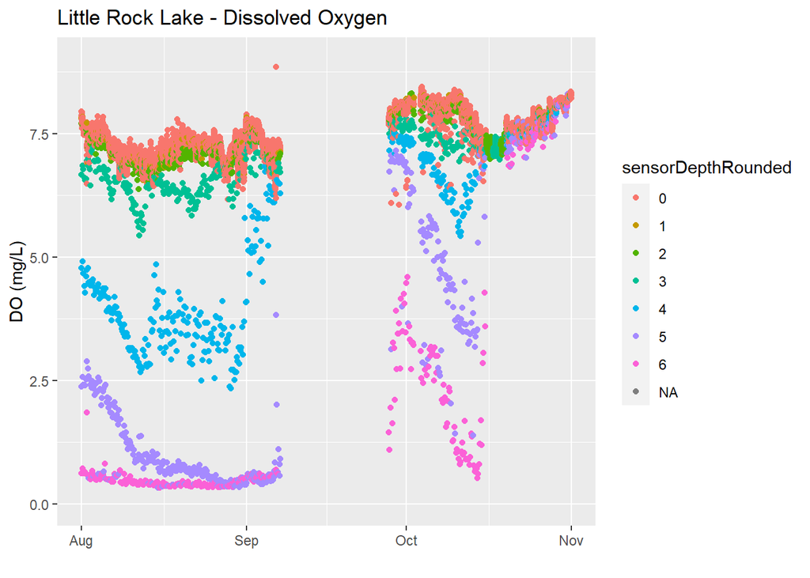

```r
# create discrete color bins by rounding to the nearest meter
waq_instantaneous$sensorDepthRounded<-as.factor(floor(waq_instantaneous$sensorDepth))

# plot
plot_DO <- ggplot()+
  geom_point(data=waq_instantaneous,aes(x=startDateTime,y=dissolvedOxygen,color=sensorDepthRounded),na.rm=TRUE) +
                    ylim(0, 9) + ylab("DO (mg/L)") + xlab(" ") +
                   ggtitle("Little Rock Lake - Dissolved Oxygen")

plot_DO
```

## Plot water temperature data

```r
# View sensor positions file
View(sensor_positions_20264)
```

Now we can plot temperature in a similar manner to dissolved oxygen.

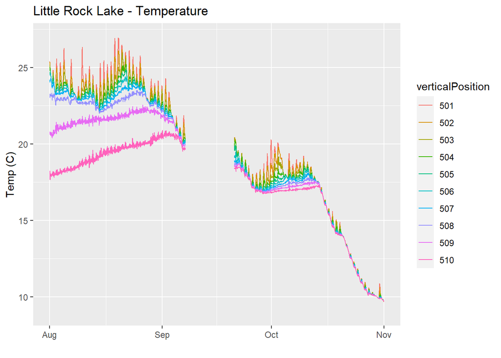

```r
# plot
plot_Temp <- ggplot()+
  geom_line(data=TSD_30_min,aes(x=endDateTime,y=tsdWaterTempMean,color=verticalPosition),na.rm=TRUE) +
                    ylim(9, 27) + ylab("Temp (C)") + xlab(" ") +
                   ggtitle("Little Rock Lake - Temperature")

plot_Temp
```

## Plot nitrate data with uncertainty

Most NEON data products are published with uncertainty values. Lets try plotting the nitrate in surface water data with uncertainty bands added.

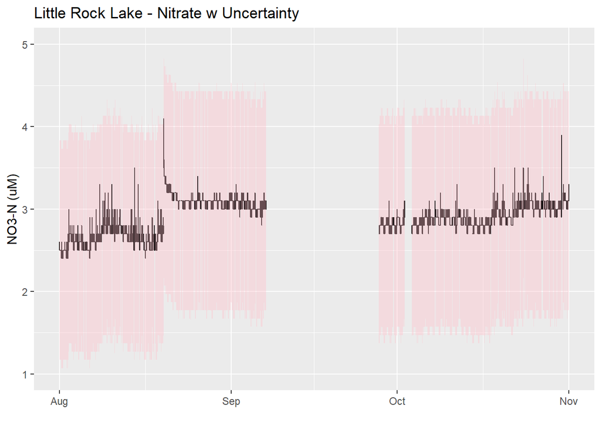

```r
# plot
plot_nsw <- ggplot() +
    geom_line(data = NSW_15_minute,
              aes(startDateTime, surfWaterNitrateMean),
              na.rm=TRUE, color="black") +
  geom_ribbon(data=NSW_15_minute,
              aes(x=startDateTime,
                  ymin = (surfWaterNitrateMean-surfWaterNitrateExpUncert),
                  ymax = (surfWaterNitrateMean+surfWaterNitrateExpUncert)),
              alpha = 0.4, fill = "pink") +
    geom_line( na.rm = TRUE) +
    ylim(1, 5) + ylab("NO3-N (uM)") +
    xlab(" ") +
  ggtitle("Little Rock Lake - Nitrate w Uncertainty")

plot_nsw
```

## Examine Quality Flagged Data

Data product quality flags fall under two distinct types:

- Automated quality flags, e.g. range, spike, step, null
- Manual science review quality flag

In instantaneous data such as water quality DP1.20288.001, the quality flag columns are denoted with “QF”.

In time-averaged data, most quality flags have been aggregated into quality metrics, with column names denoted with “QM” representing the fraction of flagged points within the time averaging window.

```r
waq_qf_names <- names(waq_instantaneous)[grep("QF", names(waq_instantaneous))]

print(paste0("Total columns in DP1.20288.001 expanded package = ",
             as.character(length(waq_qf_names))))
```

```
## [1] "Total columns in DP1.20288.001 expanded package = 120"
```

```r
# so let's just look at those corresponding to dissolved oxygen
print("dissolved oxygen columns in DP1.20288.001 expanded package:")
```

```
## [1] "dissolved oxygen columns in DP1.20288.001 expanded package:"
```

```r
print(waq_qf_names[grep("dissolvedOxygen", waq_qf_names)])
```

```
##  [1] "dissolvedOxygenRangeQF"       "dissolvedOxygenStepQF"
##  [3] "dissolvedOxygenNullQF"        "dissolvedOxygenGapQF"
##  [5] "dissolvedOxygenSpikeQF"       "dissolvedOxygenValidCalQF"
##  [7] "dissolvedOxygenSuspectCalQF"  "dissolvedOxygenPersistenceQF"
##  [9] "dissolvedOxygenAlphaQF"       "dissolvedOxygenBetaQF"
## [11] "dissolvedOxygenFinalQF"       "dissolvedOxygenFinalQFSciRvw"
```

A quality flag (QF) of 0 indicates a pass, 1 indicates a fail, and -1 indicates a test that could not be performed. For example, a range test cannot be performed on missing measurements.

Detailed quality flags test results are all available in the `package = 'expanded'` setting we specified when calling `neonUtilities::loadByProduct()`. If we had specified `package = 'basic'`, we wouldn’t be able to investigate the detail in the type of data flag thrown. We would only see the FinalQF columns.

The `AlphaQF` and `BetaQF` represent aggregated results of various QF tests, and vary by a data product’s algorithm. In most cases, an observation’s `AlphaQF = 1` indicates whether or not at least one QF was set to a value of 1, and an observation’s `BetaQF = 1` indicates whether or not at least one QF was set to value of -1.

Let’s consider what values were returned for each test.

```r
# so let us just look at those corresponding to dissolved
do_qf_names <- waq_qf_names[grep("dissolvedOxygen",waq_qf_names)]

for(col_nam in do_qf_names){
  print(paste0(col_nam, " unique values: ",
               paste0(unique(waq_instantaneous[,col_nam]),
                      collapse = ", ")))
}
```

```
## [1] "dissolvedOxygenRangeQF unique values: -1, 0"
## [1] "dissolvedOxygenStepQF unique values: -1, 0, 1"
## [1] "dissolvedOxygenNullQF unique values: 1, 0, -1"
## [1] "dissolvedOxygenGapQF unique values: 0, 1, -1"
## [1] "dissolvedOxygenSpikeQF unique values: -1, 0, 1"
## [1] "dissolvedOxygenValidCalQF unique values: 0, 1, -1"
## [1] "dissolvedOxygenSuspectCalQF unique values: 0, -1"
## [1] "dissolvedOxygenPersistenceQF unique values: 0, 1, -1"
## [1] "dissolvedOxygenAlphaQF unique values: 1, 0"
## [1] "dissolvedOxygenBetaQF unique values: 1, 0"
## [1] "dissolvedOxygenFinalQF unique values: 1, 0"
## [1] "dissolvedOxygenFinalQFSciRvw unique values: NA"
```

Now let’s consider the total number of flags generated for each quality test:

```r
# Loop across the do QF column names.
#  Within each column, count the number of rows that equal '1'.
print("FLAG TEST - COUNT")
```

```
## [1] "FLAG TEST - COUNT"
```

```r
for (col_nam in do_qf_names){
  totl_qf_in_col <- length(which(waq_instantaneous[,col_nam] == 1))
  print(paste0(col_nam,": ",totl_qf_in_col))
}
```

```
## [1] "dissolvedOxygenRangeQF: 0"
## [1] "dissolvedOxygenStepQF: 1991"
## [1] "dissolvedOxygenNullQF: 6703"
## [1] "dissolvedOxygenGapQF: 6306"
## [1] "dissolvedOxygenSpikeQF: 773"
## [1] "dissolvedOxygenValidCalQF: 5566"
## [1] "dissolvedOxygenSuspectCalQF: 0"
## [1] "dissolvedOxygenPersistenceQF: 331"
## [1] "dissolvedOxygenAlphaQF: 8715"
## [1] "dissolvedOxygenBetaQF: 12137"
## [1] "dissolvedOxygenFinalQF: 8725"
## [1] "dissolvedOxygenFinalQFSciRvw: 0"
```

```r
print(paste0("Total observations: ", nrow(waq_instantaneous) ))
```

```
## [1] "Total observations: 26496"
```

```r
print(paste0("Percent flagged: ", sum(waq_instantaneous$dissolvedOxygenFinalQF)/nrow(waq_instantaneous) ))
```

```
## [1] "Percent flagged: 0.329294987922705"
```

```r
print(paste0("Percent non-null flagged: ", (sum(waq_instantaneous$dissolvedOxygenFinalQF)-sum(waq_instantaneous$dissolvedOxygenNullQF))/(nrow(waq_instantaneous)-sum(waq_instantaneous$dissolvedOxygenNullQF))))
```

```
## [1] "Percent non-null flagged: 0.102610715548149"
```

For specific details on the algorithms used to create a data product and its corresponding quality tests, it’s best to first check the data product’s Algorithm Theoretical Basis Document (ATBD). For water quality, that is NEON.DOC.004931 listed as Documentation references in the README file and the data product’s web page.

If there any manual science review quality flags, the explanation for flagging may also be viewed in the data product’s README file or in the data product’s web page on NEON’s data portal.

## Filtering (Some) Quality Flagged Observations

A simple approach to removing quality flagged observations is to remove data when the finalQF is raised. Let’s view dissolved oxygen in the context of its final quality flags:

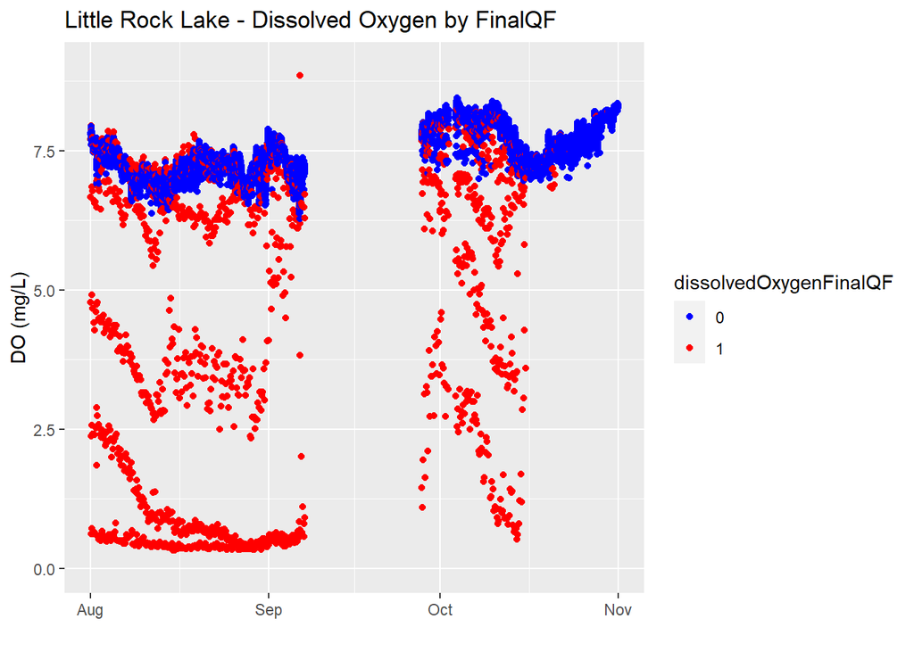

```r
# sets the QF as a a factor rather than a continuous variable
waq_instantaneous$dissolvedOxygenFinalQF<-as.factor(waq_instantaneous$dissolvedOxygenFinalQF)

# plot
plot_DO <- ggplot()+
  geom_point(data=waq_instantaneous,aes(x=startDateTime,y=dissolvedOxygen,color=dissolvedOxygenFinalQF),na.rm=TRUE) +
  scale_color_manual(values = c("0" = "blue","1"="red")) +
                    ylim(0, 9) + ylab("DO (mg/L)") + xlab(" ") +
                   ggtitle("Little Rock Lake - Dissolved Oxygen by FinalQF")

plot_DO
```

The blue points corresponding to `dissolvedOxygenFinalQF = 0` represents all data that were not flagged. Conversely, the red points corresponding to `dissolvedOxygenFinalQF = 1` represents all data that were flagged, What’s going on here? It looks like all of the measurements collected during the vertical profiles while the lake is stratified are getting flagged. Let’s create a similar plot, but using only the stepQF:

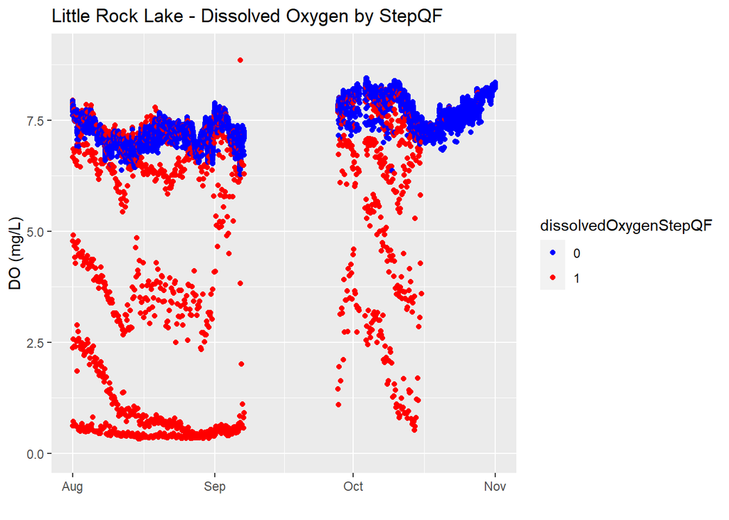

```r
# sets the QF as a a factor rather than a continuous variable
waq_instantaneous$dissolvedOxygenStepQF<-as.factor(waq_instantaneous$dissolvedOxygenStepQF)

# plot
plot_DO <- ggplot()+
  geom_point(data=waq_instantaneous,aes(x=startDateTime,y=dissolvedOxygen,color=dissolvedOxygenStepQF),na.rm=TRUE) +
  scale_color_manual(values = c("0" = "blue","1"="red")) +
                    ylim(0, 9) + ylab("DO (mg/L)") + xlab(" ") +
                   ggtitle("Little Rock Lake - Dissolved Oxygen by StepQF")

plot_DO
```

Because there is a large change from one measurement to the next during profiling, these measurements are getting an automated stepQF. In this case however, we believe these differences to be real and not the result of an erroneous measurement. This is a good example of why you should not rely solely on the automated quality flags, especially the finalQF in evaluating the data. We encourage users to download the expanded data package (which contains individual QF) as well as reading the documentation to understand how QFs are derived, before determining for yourselves which data points to include or omit in your analysis.